It is now possible to collect a large amount of data about personal movement using activity monitoring devices such as a [Fitbit](http://www.fitbit.com/), [Nike Fuelband](http://www.nike.com/us/en_us/c/nikeplus-fuelband), or [Jawbone Up](https://jawbone.com/up). These type of devices are part of the “quantified self” movement – a group of enthusiasts who take measurements about themselves regularly to improve their health, to find patterns in their behavior, or because they are tech geeks. But these data remain under-utilized both because the raw data are hard to obtain and there is a lack of statistical methods and software for processing and interpreting the data.

This assignment makes use of data from a personal activity monitoring device. This device collects data at 5 minute intervals through out the day. The data consists of two months of data from an anonymous individual collected during the months of October and November, 2012 and include the number of steps taken in 5 minute intervals each day.

The data for this assignment can be downloaded from the course web site:

- **Dataset**: [Activity monitoring data](https://d396qusza40orc.cloudfront.net/repdata%2Fdata%2Factivity.zip) [52K]
- **steps**: Number of steps taking in a 5-minute interval (missing values are coded as NA)
- **date**: The date on which the measurement was taken in YYYY-MM-DD format
- **interval**: Identifier for the 5-minute interval in which measurement was taken

The activity.zip file is unzipped and the dataset is stored in a comma-separated-value (CSV) file named activity.csv and there are a total of 17,568 observations in this dataset. The data downloaded in “Tue Jul 14 05:16:36 2020”

```r
# Loading the data
activity <- read.table(unz('../Data/Raw_data/activity.zip','activity.csv'), header=T, sep = ',')
```

Processing the data by converting the date variable to class (Date) and making a new variable named day, it will be useful for imputing the missing value strategy.

```r
# Converting variable date to class (Date)
activity$date <- as.Date(activity$date)
# adding a new variable day to be used in imputting NAs Strategy
activity$day <- format(activity$date, '%a')
```

Using the reshape2 package and calling melt() and dcast() functions to Calculate the total number of steps taken per day. Ignoring the missing values.

```r
library(reshape2)
melted_activity <- melt(activity, id=c('date', 'day', 'interval'))
# Calculate the total number of steps taken per day
steps_per_day <- dcast(melted_activity, date~variable, sum, na.rm=T)
```

to make a histogram of the total number of steps taken each day

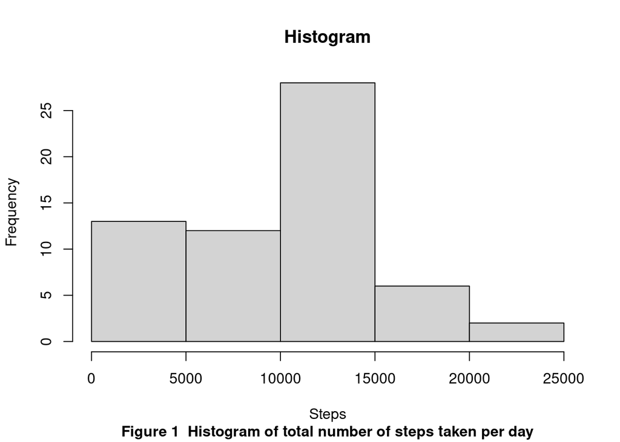

```r
# Make a histogram of the total number of steps taken each day
hist(steps_per_day$steps, main = 'Histogram', font.main=2,
     xlab='Steps', sub='Figure 1  Histogram of total number of steps taken per day', font.sub=2)
```

to calculate the mean and median of the total number of steps taken per day.

```r
steps_per_day_mean <- mean(steps_per_day$steps, na.rm = T)
steps_per_day_median <- median(steps_per_day$steps, na.rm = T)
```

the mean steps per day 9354.23 and the median is 10395.

To make a time series plot of the 5-minute interval (x-axis) and the average number of steps taken, averaged across all days (y-axis) first, by calling dcast() function.

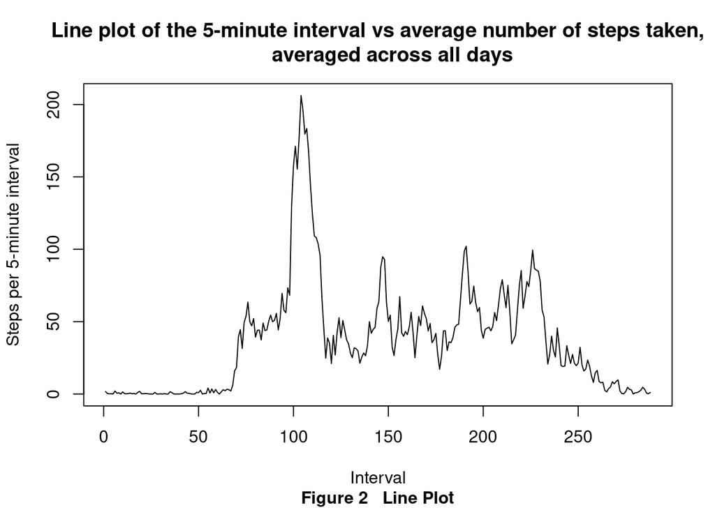

```r
# the average number of steps taken, averaged across all days
steps_per_interval <- dcast(melted_activity, interval~variable, mean, na.rm=T)

plot(steps_per_interval$steps, type='l', xlab='Interval', ylab='Steps per 5-minute interval',
     sub='Figure 2   Line Plot',
     main='Line plot of the 5-minute interval vs average number of steps taken,
     averaged across all days', font.sub=2)
```

To find which 5-minute interval, on average across all the days in the dataset, contains the maximum number of steps.

```r
#Which 5-minute interval, on average across all the days in the dataset,
#contains the maximum number of steps?
max_interval_ind <- which.max(steps_per_interval$steps)
max_interval <- steps_per_interval$interval[max_interval_ind]
```

The interval 835 contains the maximum number of steps 206.1698113.

Moving from ignoring the missing values to imput them.

```r
NA_rows <- nrow(activity[is.na(activity$steps),])
```

the total number of missing values in the dataset 2304. The strategy to fill the missing values is to substitute the missing steps with the average 5-minute interval based in the weekday.

```r
#  Substitute the missing steps with the average 5-minute interval
# based on the day of the week
cleaned_data <-activity[!is.na(activity$steps),]
melted_cleaned_data <- melt(cleaned_data, id=c('date', 'interval', 'day'))
avgTable <- dcast(melted_cleaned_data, day+interval~variable, mean)
NAs <- activity[is.na(activity$steps),]
merged <- merge(NAs , avgTable, by=c('day', 'interval'))[,-3]
names(merged)[4] <- 'steps'
imputted_activity <- rbind(merged, cleaned_data)
```

imputted_activity is new dataset that is equal to the original dataset but with the missing data are filled in.  
To make a histogram of the total number of steps taken each day after missing values are imputed.

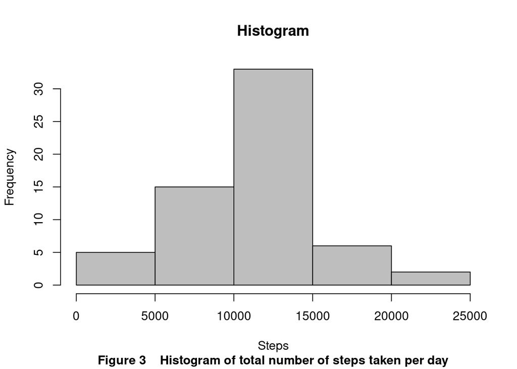

```r
# the total number of steps taken each day
melted_imputted_activity <- melt(imputted_activity,
                                 id=c('day', 'date', 'interval'))
steps_per_day_2 <- dcast(melted_imputted_activity,
                         date~variable, sum)

# Histogram of the total number of steps taken each day
# after missing values are imputed
hist(steps_per_day_2$steps, col='grey', xlab = 'Steps', main='Histogram',
     sub='Figure 3    Histogram of total number of steps taken per day'
     , font.sub=2)
```

to calculate the mean and median of the total number of steps taken per day afetr imputing the missing values

```r
steps_per_day_mean_2 <- mean(steps_per_day_2$steps)
steps_per_day_median_2 <- median(steps_per_day_2$steps)
```

after filling the missing value the mean is 10821.21 with diference 1466.98 when ignoring the missing values, and the median 11015 with diference 620.

to create a new factor variable in the dataset with two levels ‘weekday’ and ‘weekend’ indicating whether a given date is a weekday or weekend day. Casted _complete dataset is created with variable dayType which has two values ‘weekend’ or ‘weekday’.

```r
# the average number of steps taken per 5-minute interval across weekdays and weekends
imputted_activity$dayType <- ifelse(imputted_activity$day %in% c('Sat', 'Sun'),
                                    'Weekend', 'Weekday')

melted_complete <- melt(imputted_activity, id=c('date', 'interval', 'day','dayType'))
casted_complete <- dcast(melted_complete,dayType+interval~variable, mean)
```

to make a panel plot comparing the average number of steps taken per 5-minute interval across weekdays and weekends

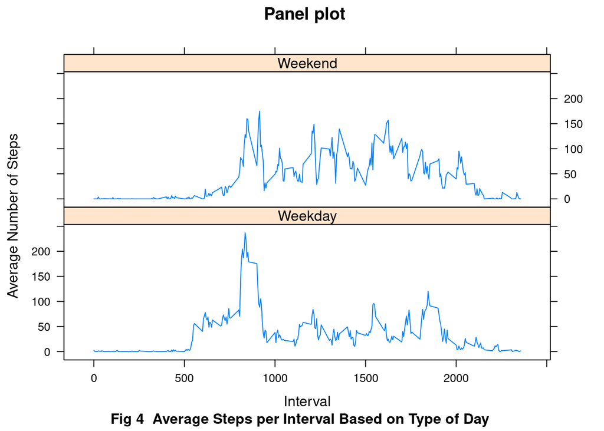

```r
# Panel plot comparing the average number of steps taken per 5-minute interval across weekdays and weekends
library(lattice)
xyplot(steps~interval|dayType, data=casted_complete, type="l",  layout = c(1,2),
       main=" Panel plot",
       ylab="Average Number of Steps", xlab="Interval",
       sub='Fig 4  Average Steps per Interval Based on Type of Day ',
       col.sub='blue', font.sub=2)
```